# **Importing Necessary Libraries For data processing and visualization**

```python
import pyspark
from pyspark.sql import SparkSession
import pandas as pd
from pyspark.sql import SQLContext
import seaborn as sns
from pyspark.sql.types import *
```

# **Creating Spark Project**

```python
spark = SparkSession.builder.appName('Big Data Application').getOrCreate()
```

# **Reading CSV files in Pandas dataframes**

```python
country=pd.read_csv("Country.csv")
newCovid_Cases=pd.read_csv("newCovid_Cases.csv")
School_open_status=pd.read_csv('School Opening Status.csv')
Location=pd.read_csv('Location Table Data.csv')
States=pd.read_csv('States Table Data.csv')
```

# **Displaying all the datasets**

```python
country.head()
```

|  | CountryID | CountryName | CountryCode |
| --- | --- | --- | --- |
| 0 | 1 | Afghanistan | AF / AFG |
| 1 | 2 | Albania | AL / ALB |
| 2 | 3 | Algeria | DZ / DZA |
| 3 | 4 | Andorra | AD / AND |
| 4 | 5 | Angola | AO / AGO |

```python
newCovid_Cases.head()
```

|  | CC_ID | ConfirmedCases | Recovered | Deaths | Date | LocationID | SS_ID | Year | Month |
| --- | --- | --- | --- | --- | --- | --- | --- | --- | --- |
| 0 | 1 | 237 | 5 | 4 | 01/04/2020 | 3 | 2.0 | 2020 | Apr |
| 1 | 2 | 273 | 10 | 6 | 02/04/2020 | 3 | 2.0 | 2020 | Apr |
| 2 | 3 | 281 | 10 | 6 | 03/04/2020 | 3 | 2.0 | 2020 | Apr |
| 3 | 4 | 299 | 10 | 7 | 04/04/2020 | 3 | 2.0 | 2020 | Apr |
| 4 | 5 | 349 | 15 | 7 | 05/04/2020 | 3 | 2.0 | 2020 | Apr |

```python
School_open_status.head()
```

|  | SS_ID | SS_Name |
| --- | --- | --- |
| 0 | 1 | Fully open |
| 1 | 2 | Closed due to COVID-19 |
| 2 | 3 | Partially open |
| 3 | 4 | Academic break |

```python
Location.head()
```

|  | LocationID | Latitude | Longitude | StateID | CountryID |
| --- | --- | --- | --- | --- | --- |
| 0 | 1 | 33.00000 | 65.000000 | NaN | 1 |
| 1 | 2 | 33.93910 | 67.710000 | NaN | 1 |
| 2 | 3 | 33.93911 | 67.709953 | NaN | 1 |
| 3 | 4 | 41.15330 | 20.168300 | NaN | 2 |
| 4 | 5 | 28.03390 | 1.659600 | NaN | 3 |

```python
States.head()
```

|  | StateID | StateName |
| --- | --- | --- |
| 0 | 1 | Abruzzo |
| 1 | 2 | Acre |
| 2 | 3 | Adygea Republic |
| 3 | 4 | Aguascalientes |
| 4 | 5 | Aichi |

# **Data Cleaning**

```python
newCovid_Cases=newCovid_Cases.fillna(0)
newCovid_Cases["SS_ID"]=newCovid_Cases["SS_ID"].round(0).astype(int)
Location=Location.fillna(0)
Location["StateID"]=Location["StateID"].round(0).astype(int)
```

# **Table Schema Specification**

```python
CountrySchema = StructType([ StructField("CountryID", IntegerType(), True)\
                      ,StructField("CountryName", StringType(), True)])
newCovid_CasesSchema = StructType([ StructField("CC_ID", IntegerType(), True)\
                       ,StructField("ConfirmedCases", IntegerType(), True)\
                       ,StructField("Recovered", IntegerType(), True)\
                       ,StructField("Deaths", IntegerType(), True)\
                       ,StructField("Date", StringType(), True)\
                       ,StructField("LocationID", IntegerType(), True)\
                       ,StructField("SS_ID", IntegerType(), True)])
School_open_statusSchema = StructType([ StructField("SS_ID", IntegerType(), True)\
                      ,StructField("SS_Name", StringType(), True)])
LocationSchema = StructType([ StructField("LocationID", IntegerType(), True)\
                       ,StructField("Latitude", StringType(), True)\
                       ,StructField("Longitude", StringType(), True)\
                       ,StructField("StateID", IntegerType(), True)\
                       ,StructField("CountryID", StringType(), True)])
StatesSchema = StructType([ StructField("StateID", IntegerType(), True)\
                      ,StructField("StateName", StringType(), True)])
```

# **Creating Spark dataframes from pandas dataframes**

```python
country_spark = spark.createDataFrame(country,schema=CountrySchema)
newCovid_Cases_spark = spark.createDataFrame(newCovid_Cases,schema=newCovid_CasesSchema)
School_open_status_spark = spark.createDataFrame(School_open_status,schema=School_open_statusSchema)
Location_spark = spark.createDataFrame(Location,schema=LocationSchema)
States_spark = spark.createDataFrame(States,schema=StatesSchema)
```

# **Converting Spark dataframe to Temp Tables to used in Spark SQL API**

```python
country_spark.createOrReplaceTempView("country_spark_temp")
newCovid_Cases_spark.createOrReplaceTempView("newCovid_Cases_spark_temp")
School_open_status_spark.createOrReplaceTempView("School_open_status_spark_temp")
Location_spark.createOrReplaceTempView("Location_spark_temp")
States_spark.createOrReplaceTempView("States_spark_temp")
```

## **Total Confirmed Cases, Total Deaths, Total Recovered cases with all school Status for each Country**

#### Through this Non Trivial Query we can see the trend of Following:

- COVID **Confirmed cases**
- **Deaths** Cases due to COVID
- **Recovered** Cases from COVID #### For each country against each School Status as below
- Academic break
- Closed due to COVID-19
- Fully open
- Partially open ### **Through that we can extract intuition that which school status effect the most for each country**

```python
query="""
select * from
(
  select
  c.countryname as Country_Name,
  d.SS_Name as School_status,
  sum(a.confirmedcases) as Confirmed_Cases, --Total Confirmed COVID Cases
  sum(a.Deaths) as Deaths, --Total Deaths cases from Confirmed COVID Cases
  sum(a.recovered) as recovered --Total Recovered cases from Confirmed COVID Cases
  from newCovid_Cases_spark_temp a
  inner join Location_spark_temp b
  on a.locationid=b.locationid
  inner join country_spark_temp c
  on b.countryid=c.countryid
  inner join School_open_status_spark_temp d
  on a.SS_ID=d.SS_ID
  group by c.countryname,d.SS_Name
)
result
order by country_name Asc
"""
result1=spark.sql(query)
result_pd=result1.toPandas()
result_pd.head(3)
```

|  | Country_Name | School_status | Confirmed_Cases | Deaths | recovered |
| --- | --- | --- | --- | --- | --- |
| 0 | Afghanistan | Closed due to COVID-19 | 1003776 | 20761 | 211824 |
| 1 | Albania | Academic break | 30295 | 797 | 17479 |
| 2 | Albania | Partially open | 40992 | 1118 | 29896 |

# **Normalizing data**

```python
result_pd["Deaths"]=result_pd["Deaths"]/100000
result_pd["Confirmed_Cases"]=result_pd["Confirmed_Cases"]/100000
result_pd["recovered"]=result_pd["recovered"]/100000
```

### **PLotting of Deaths due to COVID including all school status for each country**

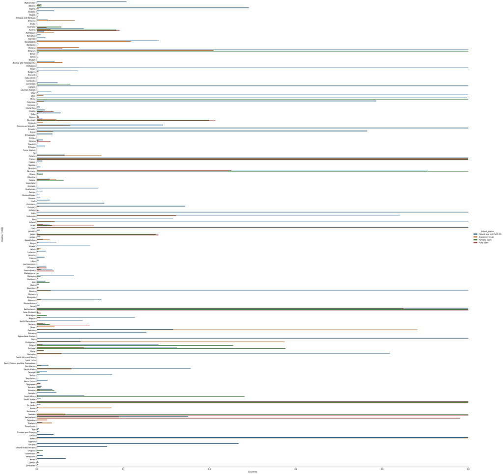

```python
g = sns.catplot(x="Deaths", y="Country_Name", hue="School_status",
               data=result_pd, kind="bar", ci=None,saturation=.5,
                orient="h",height=35)
g.set(xlim=(0, 1))
g.set_axis_labels("Countries", "Deaths / (100k)")
g.savefig("Deaths.png")
```

## **PLotting of Confirmd Covid Cases including all school status for each country**

##### We can observe in the graphs that:

- Mix of School status can be seen in the graph as the main reason of Confirmed cases in most of the countries

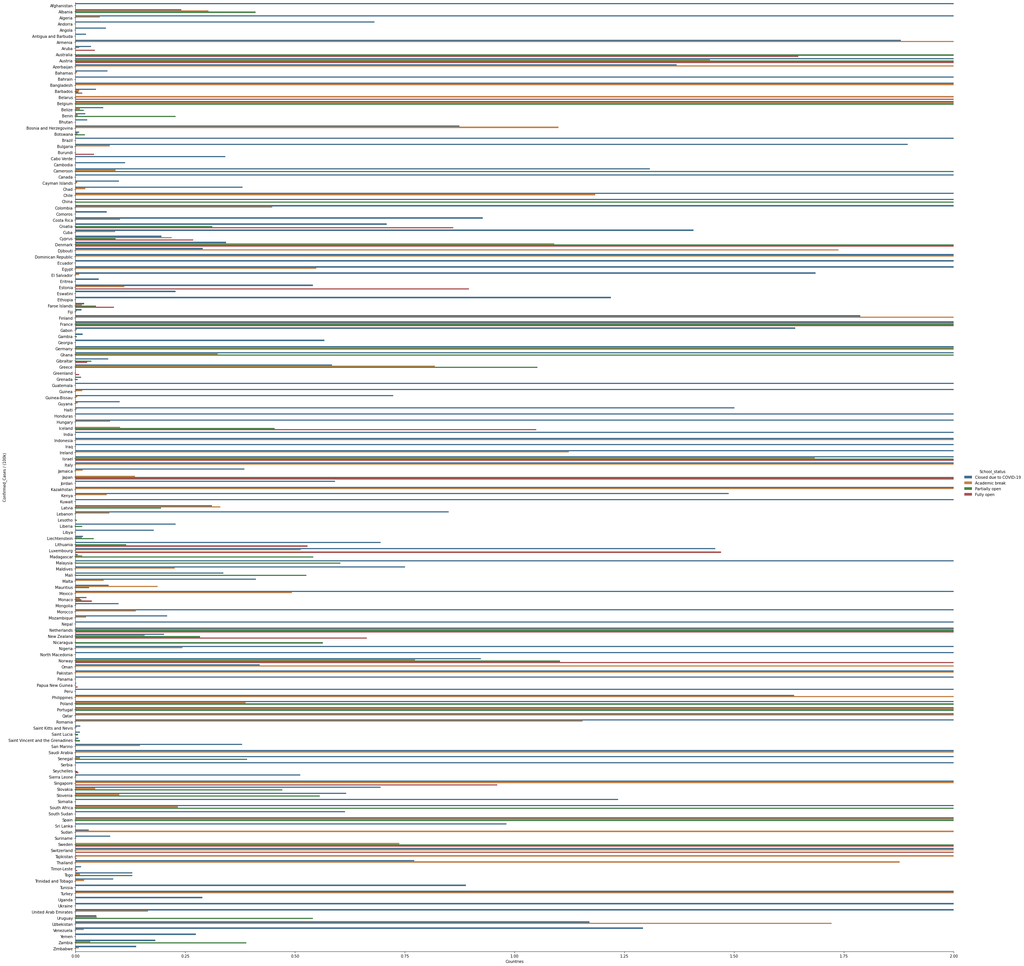

```python
import seaborn as sns
g = sns.catplot(x="Confirmed_Cases", y="Country_Name", hue="School_status",
               data=result_pd, kind="bar", ci=None,saturation=.5,
                orient="h",height=35)
g.set(xlim=(0, 2))
g.set_axis_labels("Countries", "Confirmed_Cases / (100k)")
g.savefig("Confirmed_Cases.png")
```

## **PLotting of Recovered COVID Cases including all school status for each country**

##### We can observe in the graphs that:

- **"Closed due to COVID-19"** & **Academic Break** School status can be seen in the graph as the main reason of Rcovered cases in most of the countries

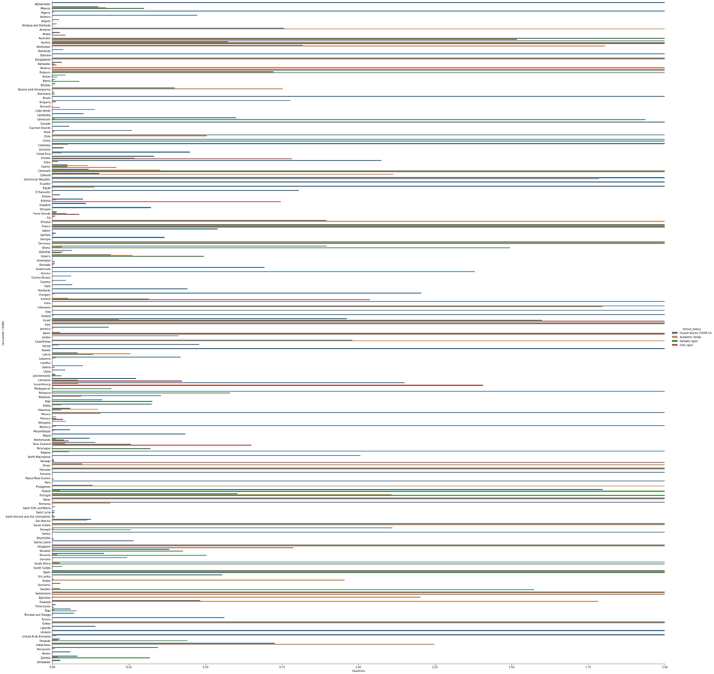

```python
import seaborn as sns
g = sns.catplot(x="recovered", y="Country_Name", hue="School_status",
               data=result_pd, kind="bar", ci=None,saturation=.5,
                orient="h",height=35)
g.set(xlim=(0, 2))
g.set_axis_labels("Countries", "recovered / (100k)")
g.savefig("recovered.png")
```

## **Total Confirmed Cases, Deaths and recovered cases including all school status for each month.**

#### Through this Non Trivial Query we can see the trend of Following:

- COVID **Confirmed cases**
- **Deaths** Cases due to COVID
- **Recovered** Cases from COVID #### For three months **April**, **May**, **June** respectively against each School Status as below
- Academic break
- Closed due to COVID-19
- Fully open
- Partially open ### **Through that we can extract intuition that which school status effect the most for each month**

```python
query="""select * from (
select
case
when extract(months from date) == 4 then 'April'
when extract(months from date) == 5 then 'May'
when extract(months from date) == 6 then 'June'
end Month,

d.SS_Name School_status,
sum(a.confirmedcases) Confirmed_Cases,
sum(a.Deaths) Deaths,
sum(a.recovered) recovered
from newCovid_Cases_spark_temp a
inner join Location_spark_temp b on a.locationid=b.locationid
inner join country_spark_temp c on b.countryid=c.countryid
inner join School_open_status_spark_temp d on a.SS_ID=d.SS_ID
group by d.SS_Name,
case
when extract(months from date) == 4 then 'April'
when extract(months from date) == 5 then 'May'
when extract(months from date) == 6 then 'June'
end ) result
order by School_status asc,
case
when month='April' then 1
when month='May' then 2
when month='June' then 3 end
"""
result2=spark.sql(query)
result_pd2=result2.toPandas()
result_pd2.head(3)
```

|  | Month | School_status | Confirmed_Cases | Deaths | recovered |
| --- | --- | --- | --- | --- | --- |
| 0 | April | Academic break | 10526422 | 880169 | 2909167 |
| 1 | May | Academic break | 3614069 | 105660 | 1371687 |
| 2 | June | Academic break | 23278192 | 862427 | 14483353 |

```python
result_pd2["Confirmed_Cases"]=result_pd2["Confirmed_Cases"]/100000
result_pd2["Deaths"]=result_pd2["Deaths"]/100000
result_pd2["recovered"]=result_pd2["recovered"]/100000
```

## **Plotting Total Confirmed Cases, Deaths and recovered cases including all school status for each month**

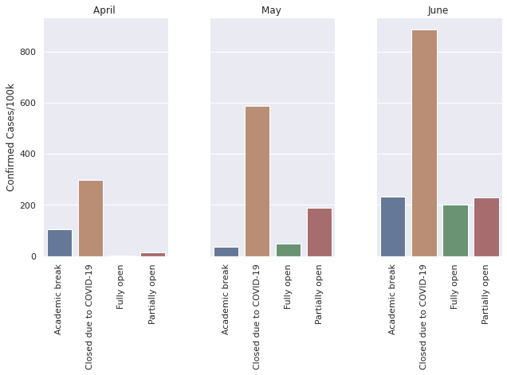

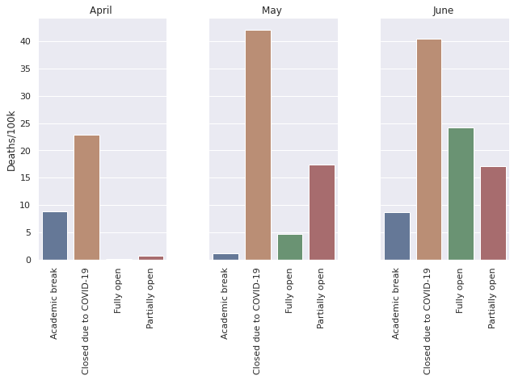

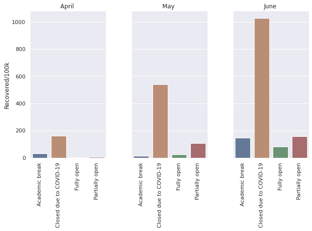

```python
g1 = sns.catplot(ax=axes[0],x="School_status", y="Confirmed_Cases", col="Month",
                data=result_pd2, saturation=.5,
                kind="bar", ci=None, aspect=.6)
(g1.set_axis_labels("", "Confirmed Cases/100k")
  .set_xticklabels(['Academic break', 'Closed due to COVID-19', 'Fully open','Partially open'])
  .set_titles("{col_name} ")
  # .set(ylim=(0, 1))
  .set_xticklabels(rotation=90)
  .despine(left=True))

g2 = sns.catplot(ax=axes[1],x="School_status", y="Deaths", col="Month",
                data=result_pd2, saturation=.5,
                kind="bar", ci=None, aspect=.6)
(g2.set_axis_labels("", "Deaths/100k")
  .set_xticklabels(['Academic break', 'Closed due to COVID-19', 'Fully open','Partially open'])
  .set_titles("{col_name} ")
  # .set(ylim=(0, 1))
  .set_xticklabels(rotation=90)
  .despine(left=True))


g3 = sns.catplot(ax=axes[2],x="School_status", y="recovered", col="Month",
                data=result_pd2, saturation=.5,
                kind="bar", ci=None, aspect=.6)
(g3.set_axis_labels("", "Recovered/100k")
  .set_xticklabels(['Academic break', 'Closed due to COVID-19', 'Fully open','Partially open'])
  .set_titles("{col_name} ")
  # .set(ylim=(0, 1))
  .set_xticklabels(rotation=90)
  .despine(left=True))
g1.savefig("Confirmed_Cases2.png")
g2.savefig("Death2.png")
g3.savefig("Recovered2.png")
```

### **Total Confirmed Cases, Deaths and recovered cases including all school status for each country with the long lat for each location**

#### Through this Non Trivial Query we can see the trend of Following:

- COVID **Confirmed cases**
- **Deaths** Cases due to COVID
- **Recovered** Cases from COVID #### For each Country with their respective locations (longitude and latidtude) and each school Status as below
- Academic break
- Closed due to COVID-19
- Fully open
- Partially open ### **Through that we can see the trend of Confirmed cases, Deaths and Recovered across the globe**

```python
query="""select * from (
select
d.SS_Name School_status,
b.locationid,b.longitude,b.latitude,c.countryname,
sum(a.confirmedcases) Confirmed_Cases,
sum(a.Deaths) Deaths,
sum(a.recovered) recovered
from newCovid_Cases_spark_temp a
inner join Location_spark_temp b on a.locationid=b.locationid
inner join country_spark_temp c on b.countryid=c.countryid
inner join School_open_status_spark_temp d on a.SS_ID=d.SS_ID
group by d.SS_Name,b.locationid,b.longitude,b.latitude,c.countryname
) result
order by locationid,longitude,latitude,countryname
"""
result3=spark.sql(query)
result_pd3=result3.toPandas()
result_pd3.head(3)
```

|  | School_status | locationid | longitude | latitude | countryname | Confirmed_Cases | Deaths | recovered |
| --- | --- | --- | --- | --- | --- | --- | --- | --- |
| 0 | Closed due to COVID-19 | 3 | 67.709953 | 33.93911 | Afghanistan | 1003776 | 20761 | 211824 |
| 1 | Closed due to COVID-19 | 4 | 20.1683 | 41.1533 | Albania | 24098 | 1009 | 15029 |
| 2 | Academic break | 4 | 20.1683 | 41.1533 | Albania | 30295 | 797 | 17479 |

```python
import pandas as pd
from shapely.geometry import Point
import geopandas as gpd
from geopandas import GeoDataFrame
result_pd3=result3.toPandas()
result_pd3['longitude']=result_pd3['longitude'].astype(float)
result_pd3['latitude']=result_pd3['latitude'].astype(float)
df = result_pd3
```

## **Plotting Total Confirmed Cases, Deaths and recovered cases for each location based on longitude and latitude**

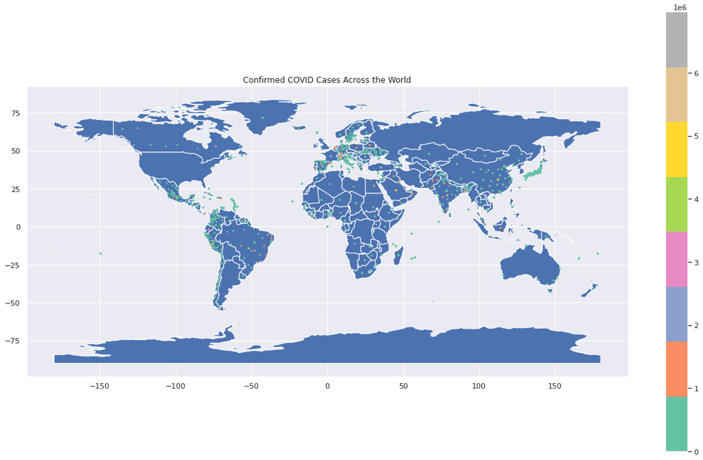

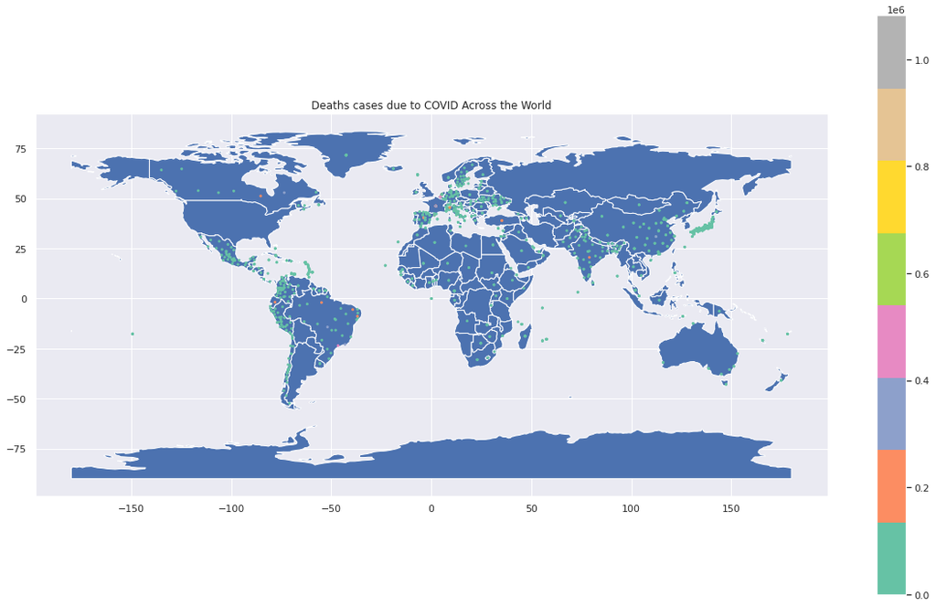

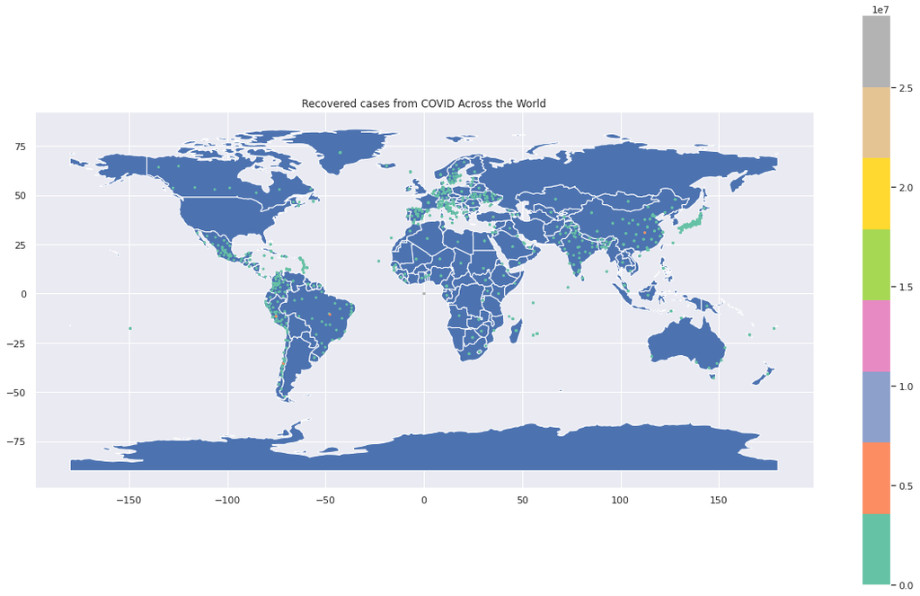

```python
geometry = [Point(xy) for xy in zip(df['longitude'], df['latitude'])]
gdf = GeoDataFrame(df, geometry=geometry)

#this is a simple map that goes with geopandas
world = gpd.read_file(gpd.datasets.get_path('naturalearth_lowres'))
Confirmed_Cases=gdf.plot(ax=world.plot(figsize=(20, 12)), marker='o', markersize=4,column='Confirmed_Cases', cmap='Set2',legend=True)
Confirmed_Cases.set_title("Confirmed COVID Cases Across the World")
plt.savefig('Confirmed_Cases.jpg')
Deaths=gdf.plot(ax=world.plot(figsize=(20, 12)), marker='o', markersize=4,column='Deaths', cmap='Set2',legend=True)
Deaths.set_title("Deaths cases due to COVID Across the World")
plt.savefig('Deaths.jpg')
recovered=gdf.plot(ax=world.plot(figsize=(20, 12)), marker='o', markersize=4,column='recovered', cmap='Set2',legend=True)
recovered.set_title("Recovered cases from COVID Across the World")
plt.savefig('recovered.jpg')
```